# StatBI/E Week 2

[This is how exercises are highlighted]

[This is how your answers are highlighted]

# Exercise 1: A trigonometric density

Let $f(x|k) \propto \sin(x)^k$ be a family of (non-normalized) densities on the interval $[0, \pi]$, parameterised by $k = 1,2,\ldots$.

## Exercise 1.1

Define a function `dsin` that implements the normalized density $f(x|k)$. It has to behave similar to other density functions in R, for example, similar to `dexp` and `dnorm` the argument must be called `x` and can be a general numerical vector. Moreover, the function must accept an additional parameter `k` with default value $1$ (the parameter of the family $f(x|k)$).

First, we plot the non-normalized densities for different values of $k$.

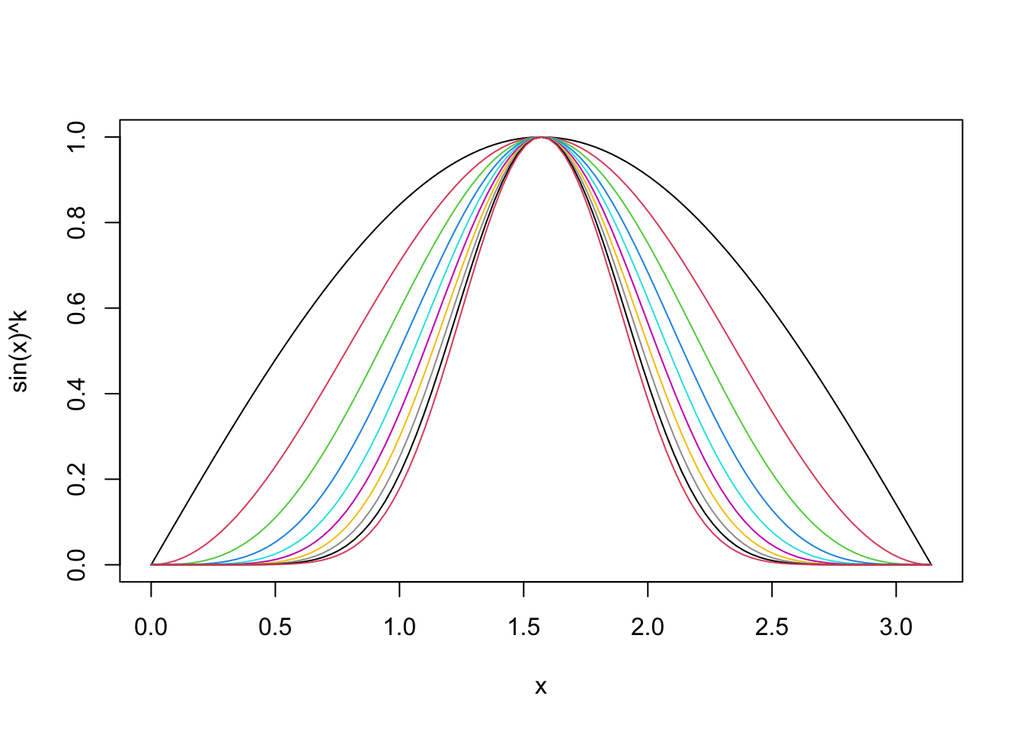

```r
temp <- FALSE
for (k in 1:10) {
  curve(
    sin(x) ^ k,
    col = k,
    add = temp,
    from = 0,
    to = pi
  )
  temp <- TRUE
}
```

As we can see the functions $\sin(x)^k$ are non-negative in the interval $[0,\pi]$, but they are not probability density functions as they do not integrate to $1$. To see this you may, for example, run the following for varying values of $k$:

```r
k <- 2
integrate(
  function(x) {
    sin(x) ^ k},
  lower = 0,
  upper = pi)
```

```
## 1.570796 with absolute error < 1.7e-14
```

To implement a proper probability density function, we have to normalize appropriately. That is, we have to find the denominator in
$$f(x|k) = \frac{\sin(x)^k}{\int_0^{\pi} \sin(t)^k dt}.$$

```r
dsin <- function(x, k = 1) {
  const <- integrate(
    function(t) sin(t) ^ k,
    lower = 0,
    upper = pi)$value
  tmp <- (sin(x) ^ k) / const
  tmp[x < 0] <- 0
  tmp[x > pi] <- 0
  return(tmp)
}
```

We plot some of the densities

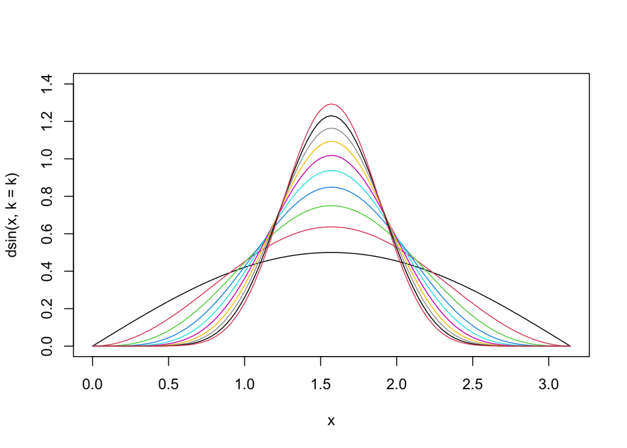

```r
temp <- FALSE
for (k in 1:10) {
  curve(
    dsin(x, k = k),
    col = k,
    add = temp,
    from = 0,
    to = pi,
    ylim =  c(0,1.4))
  temp <- TRUE
}
```

and verify that they now integrate to $1$

```r
all(abs(sapply(1:20,
               function(i)
                 integrate(
                   dsin,
                   lower = 0,
                   upper = pi,
                   k = i
                 )$value)
        - 1) < 1e-15)
```

```
## [1] TRUE
```

Note: We verify, that the integrals are close to $1$, as we evaluate them numerically and not exactly.

## Exercise 1.2

Define, similarly to other CDF functions in R, a function `psin` that implements the CDF corresponding to `dsin`.

Recall the definition of a CDF
$$F_X(x) = \int_{-\infty}^x f_X(x)dx = P(X \leq x)$$

```r
psin <- Vectorize(
  function(q, k = 1) {
    if (q > pi) {
      return(1)
    }
    if (q < 0) {
      return(0)
    }
    const <- integrate(
      function(t) sin(t) ^ k,
      lower = 0,
      upper = pi)$value
    integrate(
      function(t) sin(t) ^ k,
      lower = 0,
      upper = q)$value / const
    },
  vectorize.args = "q")
```

## Exercise 1.3

Produce plots of both the density and the CDF for different values of the parameter $k$. Make the plot look nice, with colours, a legend, etc.

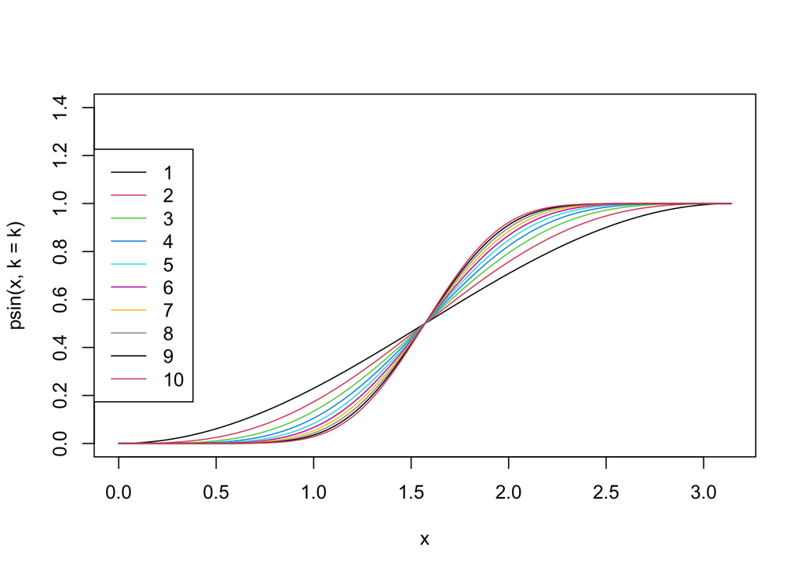

```r
temp <- FALSE
for (k in 1:10) {
  curve(
    psin(x, k = k),
    col = k,
    add = temp,
    from = 0,
    to = pi,
    ylim =  c(0, 1.4)
  )
  temp <- TRUE
}
legend("left",
       legend = 1:10,
       col = 1:10,
       lty = 1)
```

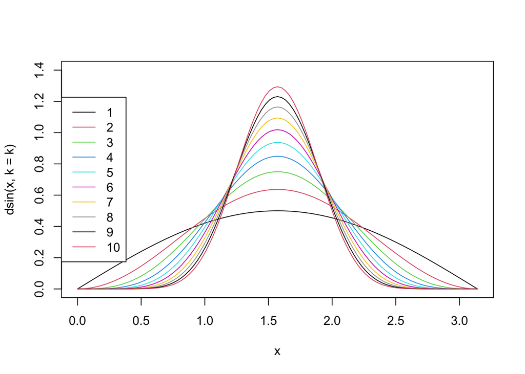

```r
temp <- FALSE
for (k in 1:10) {
  curve(
    dsin(x, k = k),
    col = k,
    add = temp,
    from = 0,
    to = pi,
    ylim =  c(0, 1.4)
  )
  temp <- TRUE
}
legend("left",
       legend = 1:10,
       col = 1:10,
       lty = 1)
```

## Exercise 1.4

Obtain variance and expected value for different values of $k$.

To obtain variance and expected value we again use the `integrate` function.

```r
k <- 5
# moment of order 1, the mean value
m1 <- integrate(function(x)
  x * dsin(x, k),
  lower = 0,
  upper = pi)$value
# moment of order 2
m2 <- integrate(function(x)
  x ^ 2 * dsin(x, k),
  lower = 0,
  upper = pi)$value
paste("Mean:", m1, "Variance:", m2 - m1 ^ 2)
```

```
## [1] "Mean: 1.5707963267949 Variance: 0.165178878050118"
```

The distributions are symmetric around $\pi/2$ thus the mean value should always be $\pi/2$; we verify this.

```r
sapply(
  1:10,
  function(k) {
    integrate(
    function(x) x*dsin(x, k),
    lower = 0,
    upper = pi)$value
    }
  )
```

```
##  [1] 1.570796 1.570796 1.570796 1.570796 1.570796 1.570796 1.570796 1.570796
##  [9] 1.570796 1.570796
```

The variance decreases with $k$.

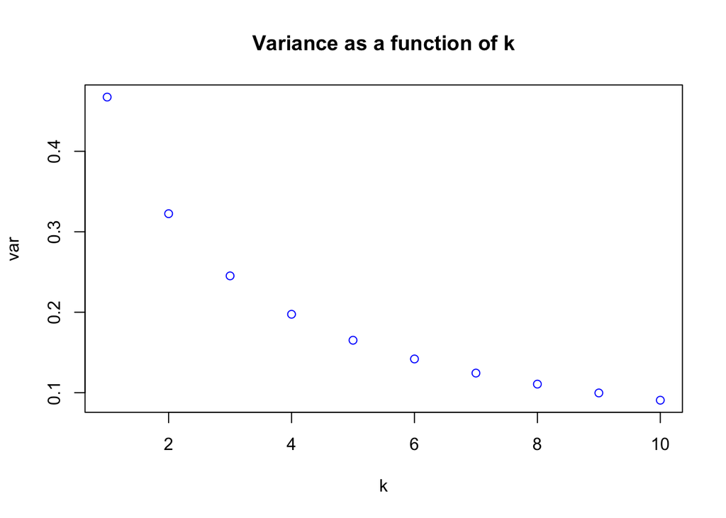

```r
vars <- sapply(1:10,
               function(k) {
                 m1 <- integrate(
                   function(x) x * dsin(x, k),
                   lower = 0,
                   upper = pi)$value
                 m2 <- integrate(
                   function(x) x^2 * dsin(x, k),
                   lower = 0,
                   upper = pi)$value
                 return(m2 - m1 ^ 2)
               })
plot(
  1:10,
  vars,
  main = "Variance as a function of k",
  xlab = "k",
  ylab = "var",
  col = "blue"
)
```

## Optional Bonus Exercise 1.5

Try to implement the *inverse transform sampling* method for this density function.

First, we define the quantile function:

```r
qsin <- function(p, k = 1) {
  uniroot(function(x)
    psin(x, k) - p,
    interval = c(0, pi),
    extendInt = "upX")$root
}

# should equal pi/2
qsin(psin(pi / 2, k = 5), k = 5)
```

```
## [1] 1.570796
```

Then, we define `rsin` via inverse transform sampling:

```r
rsin <- function(n, k = 1) {
  return(sapply(runif(n), qsin, k = k))
}

rsin(10)
```

```
##  [1] 1.4227484 2.0930997 0.4690335 1.6512016 0.6227261 1.8362835 1.7979645
##  [8] 2.5070551 2.5181350 1.1996718
```

## Optional Bonus Exercise 1.6

Test the sampling procedure implemented in the previous exercise, plotting a histogram of the generated data and the real density.

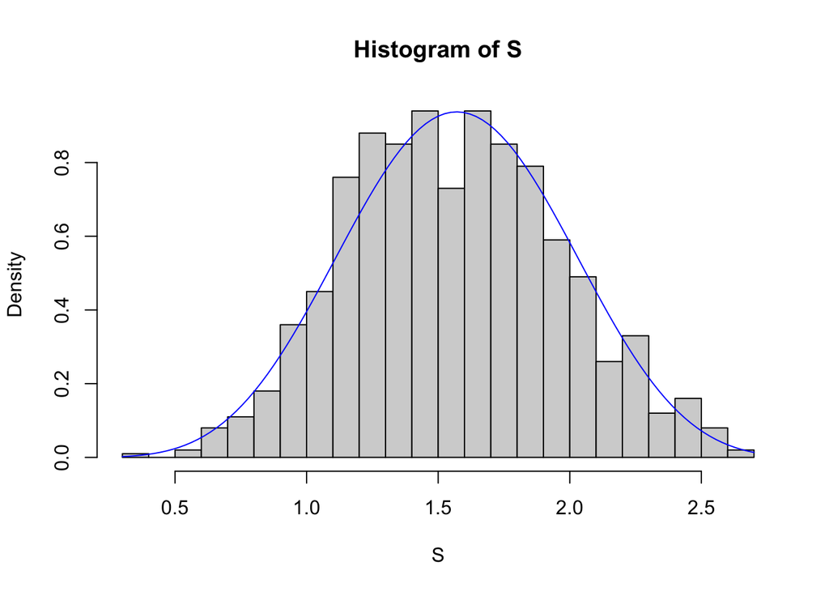

```r
k <- 5
S <- rsin(1000, k = k)
hist(S, probability = TRUE, breaks = "FD")
curve(dsin(x, k), add = TRUE, col = "blue")
```

We repeat it for $k = 12$

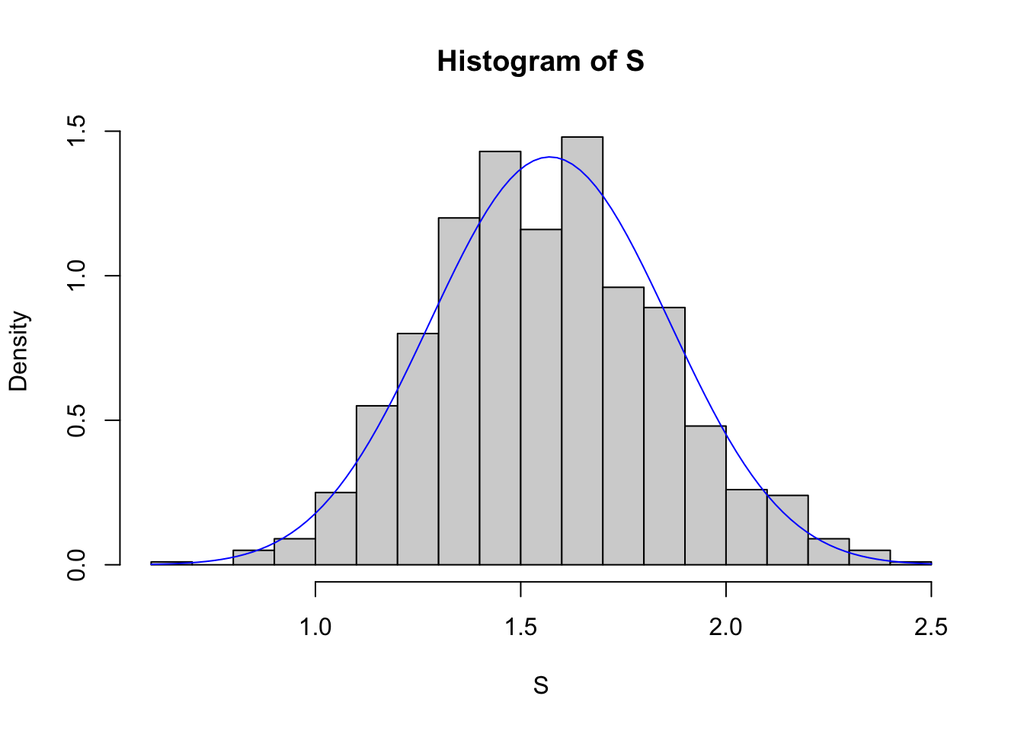

```r
k <- 12
S <- rsin(1000, k = k )
hist(S, probability = TRUE, breaks = "FD")
curve(dsin(x, k), add = TRUE, col = "blue")
```

And $k = 1$

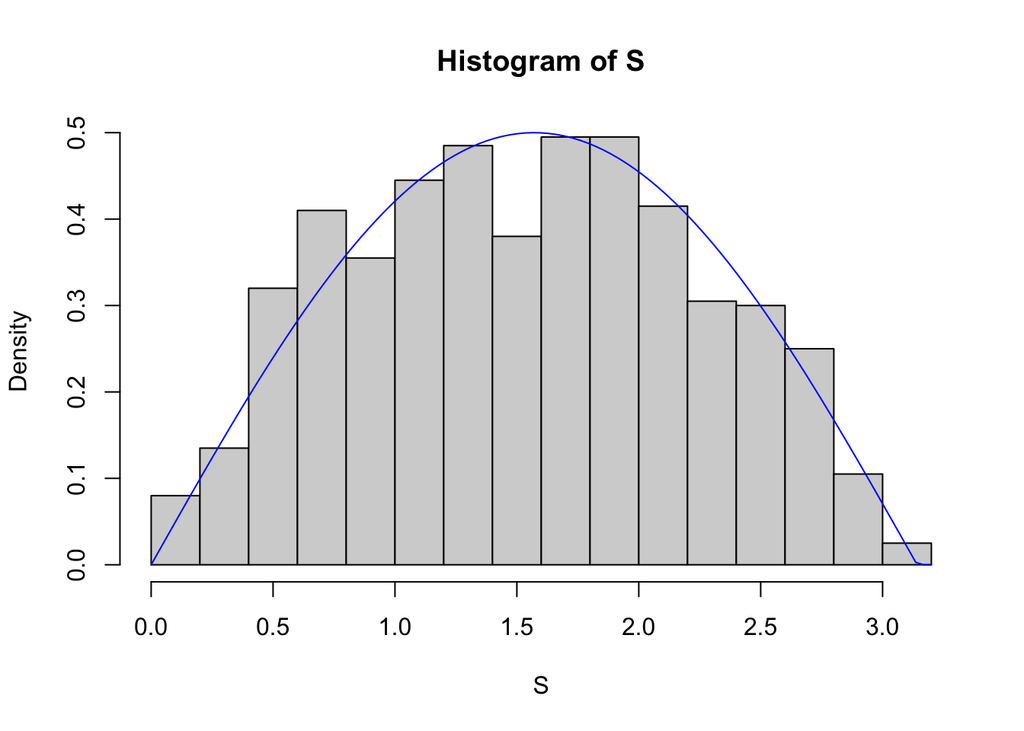

```r
k <- 1
S <- rsin(1000, k = k )
hist(S, probability = TRUE, breaks = "FD")
curve(dsin(x, k), add = TRUE, col = "blue")
```

# Exercise 2 A case study of neuronal data

Neurons work by generating and propagating, action potentials, called ‘spikes’. The time interval between two adjacent spikes, or inter-spike interval (ISI), is often used in computational neuroscience. In the file `neuronspikes.txt` you can find some ISI measurements.

To load the data in R, you can use the following line:

```
isidata <- read.table("neuronspikes.txt", col.names = "isi")
```

We load the data

```r
isidata <- read.table("neuronspikes.txt", col.names = "isi")
# here we have the vector of observations
isi <- isidata$isi
```

## Exercise 2.1

Plot the histogram of the ISI data using the function `hist`, try with different values for the `breaks` parameter. For the remainder, we will use `breaks = 50`. Moreover, use the argument `probability = TRUE` to plot probabilities.

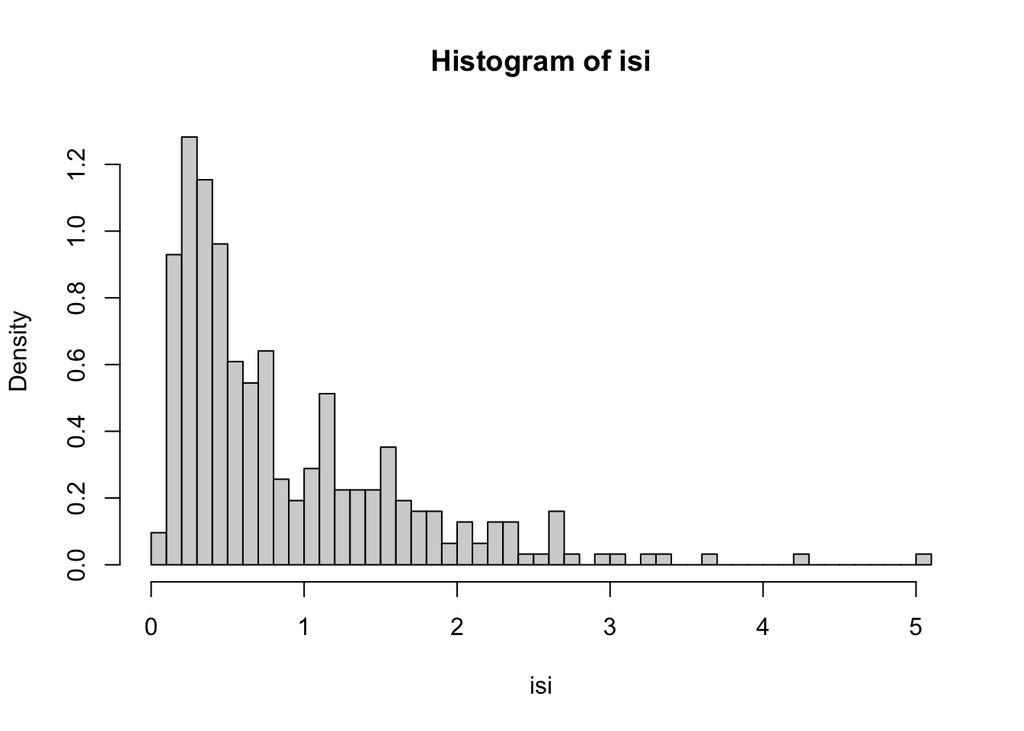

```r
hist(isi, breaks = 50, probability = TRUE)
```

## Exercise 2.2

As a first approximation we can use the exponential distribution, that is often used to describe intervals between events, such as, for example, neural spikes. The density of the exponential distribution is $f(x) = \lambda e^{-\lambda x}$, and in R we can use the `dexp` function where the $\lambda$ parameter is called `rate`. Plot the densities of the exponential distribution on top of the histogram of the ISI data for different values of the parameter $\lambda = 0.5, 0.6, \ldots, 1.4, 1.5$. Which values of $\lambda$ do you think lead to a better fit to the data?

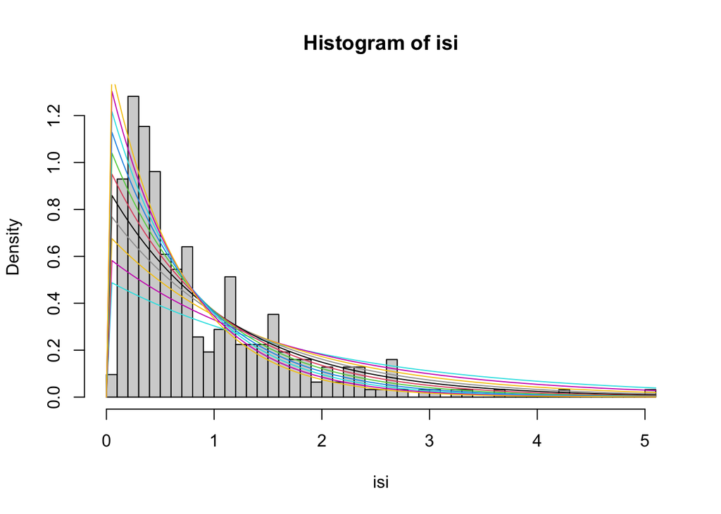

```r
hist(isi, breaks = 50, probability = TRUE)
for (rate in seq(0.5, 1.5, 0.1)) {
  curve(dexp(x, rate = rate), add = TRUE, col = rate * 10)
}
```

Maybe a good choice for the parameter can be $\lambda = 1.15$

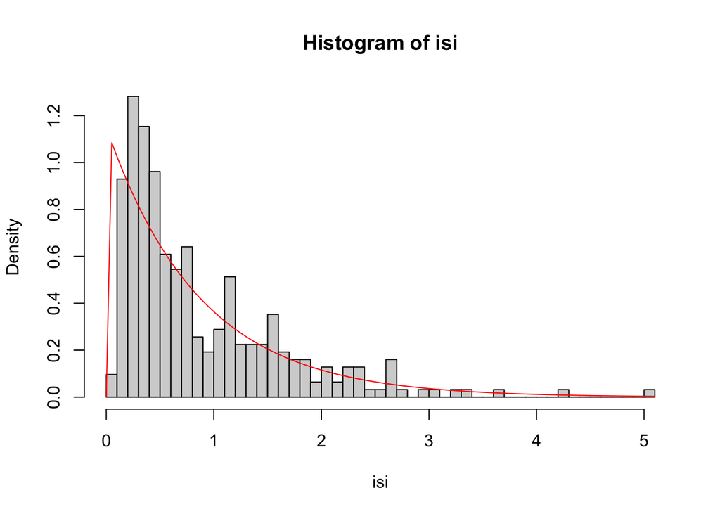

```r
hist(isi, breaks = 50, probability = TRUE)
curve(dexp(x, rate = 1.15), col = "red", add = TRUE)
```

## Exercise 2.3

Using a value $\lambda^*$ that you decided on in the previous exercise, find the value of $P( X \leq 1)$ and the value of $P( X \in [0.5, 1.5] )$ (where $X$ is the random variable that records the ISI value and we assume $X \sim \exp(\lambda^*)$). Remember that in R we can compute the CDF of a random variable with exponential distribution using the function `pexp`. The CDF $F_X$ is defined as
$$F_X(x) = P(X \leq x)
.$$

```r
rate <- 1.15

pexp(1, rate = rate)
```

```
## [1] 0.6833632
```

```r
pexp(1.5, rate = rate) - pexp(0.5, rate = rate)
```

```
## [1] 0.3845318
```

## Exercise 2.4

Make a Q-Q plot of the ISI data against the exponential distribution with parameter $\lambda = 1.15$.

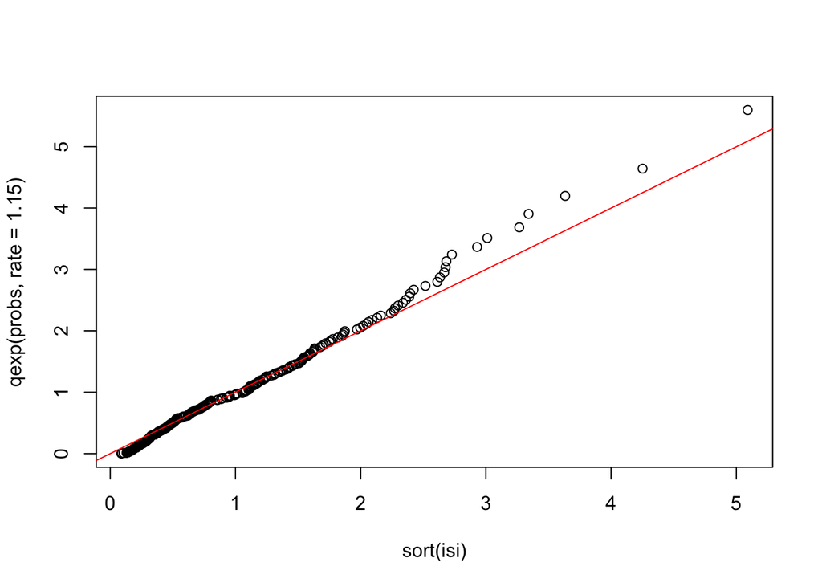

```r
probs <- ppoints(isi)
plot(sort(isi), qexp(probs, rate = 1.15))
abline(a = 0, b = 1, col = "red")
```

## Exercise 2.5

Make a Q-Q plot of the ISI data against the gamma distribution with parameters `shape = 1.56` and `rate = 1.79`.

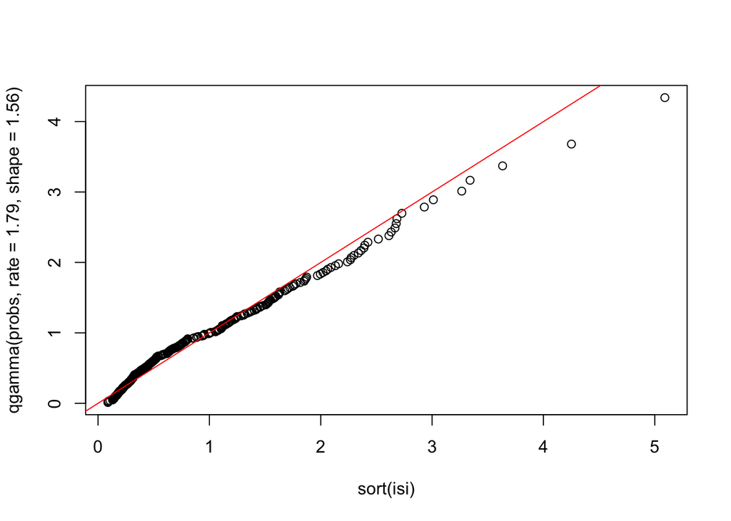

```r
probs <- ppoints(isi)
plot(sort(isi), qgamma(probs, rate = 1.79, shape = 1.56))
abline(a = 0, b = 1, col = "red")
```

## Exercise 2.6

Additionally plot the identity line in both Q-Q plots above. How do the Q-Q plots compare?